# Zia’s data

Kathleen

2023-02-14

# Analysis of NumProbes

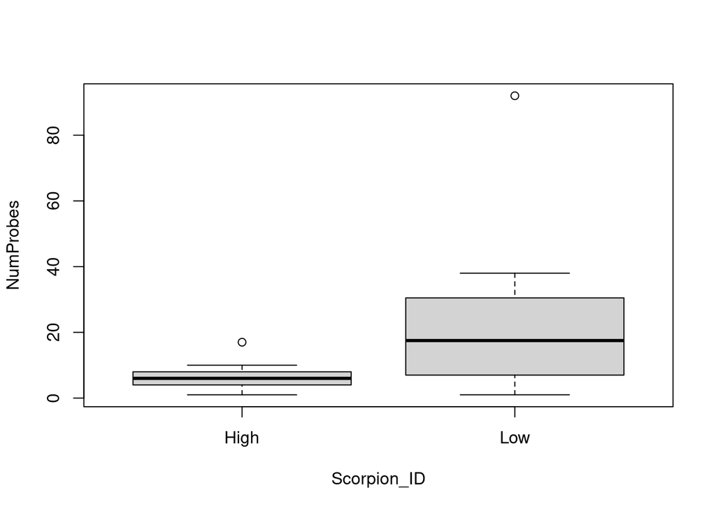

```r
boxplot(NumProbes~Scorpion_ID,data=mydata)
```

The scorpion_ID with a lower temperature looks to have a higher rate in the Number of Probes compared to the higher temperature of the scorpion_ID where it consists a lower Number of Probes.

Numerical Data

```r
favstats(NumProbes~Scorpion_ID,data=mydata)
```

```
##   Scorpion_ID min  Q1 median    Q3 max mean        sd  n missing
## 1        High   1 4.5    6.0  7.50  17  6.5  4.253341 12       0
## 2         Low   1 8.0   17.5 29.75  92 23.5 24.570862 12       0
```

Results with a higher temperature carries a lower median of 6.0 compared to the lower temperature where it’s medium consists of 17.5. Taking a closer look at the average amount of probes for the higher temperature carries the number 6.5 while the average amount of probes located in the lower temperature is 23.5.

Inferential Data

```r
t.test(NumProbes~Scorpion_ID,data=mydata)
```

```
##
##  Welch Two Sample t-test
##
## data:  NumProbes by Scorpion_ID
## t = -2.3616, df = 11.659, p-value = 0.03651
## alternative hypothesis: true difference in means between group High and group Low is not equal to 0
## 95 percent confidence interval:
##  -32.735234  -1.264766
## sample estimates:
## mean in group High  mean in group Low
##                6.5               23.5
```

In conclusion, the difference between the two recordings of data differentiated by temperature carry a large difference. Where the lower temperature requires a larger amount of probing compared to scorpions in a higher temperature. This statement can be proven through the three data charts showing the differences.

# Analysis of TimeSting

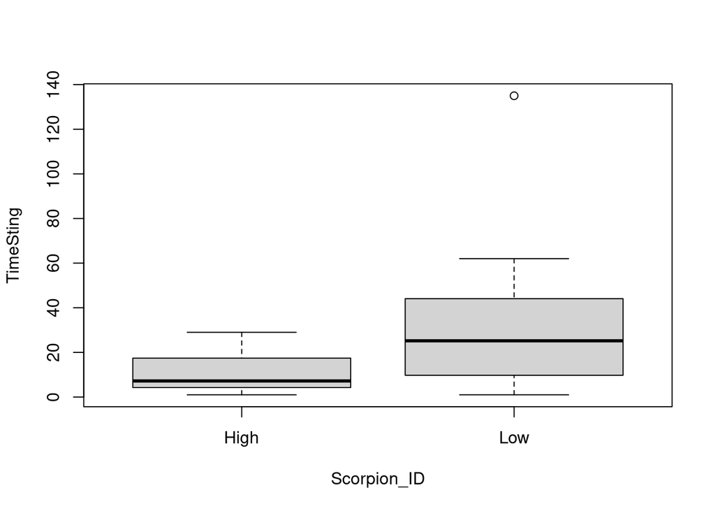

```r
boxplot(TimeSting~Scorpion_ID,data=mydata)
```

Looking at the provided data, it appears that the scorpion took more time in trying to sting when presented at a lower temperature. When presented at a higher temperature, it took less time for the stings to occur.

Numerical Data

```r
favstats(TimeSting~Scorpion_ID,data=mydata)
```

```
##   Scorpion_ID min     Q1 median       Q3 max     mean        sd  n missing
## 1        High   1  4.500    7.2 16.90625  29 11.03792  8.616193 12       0
## 2         Low   1 11.475   25.2 43.61250 135 34.42917 36.574646 12       0
```

Looking at the presented data, scorpions stuck in a higher temperature have a median of 7.2 and a mean of 11.03792. Comparing this to the other scorpion stuck in a lower temperature where the median consists of 25.2 and a mean of 34.42917.

Inferential Data

```r
t.test(TimeSting~Scorpion_ID,data=mydata,conf.level=.99)
```

```
##
##  Welch Two Sample t-test
##
## data:  TimeSting by Scorpion_ID
## t = -2.1564, df = 12.217, p-value = 0.05165
## alternative hypothesis: true difference in means between group High and group Low is not equal to 0
## 99 percent confidence interval:
##  -56.41756   9.63506
## sample estimates:
## mean in group High  mean in group Low
##           11.03792           34.42917
```